# L8

2023-04-27

## [Polynomial Linear Models](https://github.com/matloff/qeML/blob/master/inst/mdFiles/ML_Overview.md#polynomial-linear-models)

> Some people tend to shrink when they become older. Thus we may wish to model a tendency for people to gain weight in middle age but then lose weight as seniors, a **nonlinear relation**.

> We could try a quadratic model:
> - $m(height,age) = β_{0} + β_{1}\ height + β_{2}\ age + β_3\ age^{2}$
> - Presumably β<sub>3</sub> < 0, since we want a negative quadratic representation (downward parabola might best represent weight over time)

> We may even include a height * age product term, allowing for interactions. Polynomials of degree 3 and so on could also be considered.

We could add many feature transformations as additional features, such as:

- height * age
- height^2 * age
- height * age^2
- etc…

As we increase the polynomial degree, the number of possible transformations and combinations of these increases exponentially

Adding too many transformed features leaves us **prone to overfitting**

> Forming the polynomial terms by hand would be tedious, especially since we would also have to do this for predicting new cases. Instead, we use **qePolyLin** (regression setting) and **qePolyLog** (classification). They make use of the package **polyreg**.

For a dummy variable (i.e. 1 - catcher, 0 - not catcher), transformations might not alter the value, for example:

- If catcher == 0, catcher^2 is also 0
- If catcher == 1, catcher^2 is also 1
- **qePolyLin** will be smart enough to not create these unneccessary transformations from dummy variables

## [Shrinkage Methods](https://github.com/matloff/qeML/blob/master/inst/mdFiles/ML_Overview.md#shrinkage-methods-for-lineargeneralized-linear-models)

Say we’re interested in mean(height) and mean(weight)

- If we have 100 people, we would simply find the mean height and weight; these would create your estimate for your new vector

Say we’re interested in mean(height), mean(weight), and mean(age)

- If you have 3+ dimensions/variables, simply using mean height, weight, and age is no longer optimal
- We instead may want to shrink the estimated b_i

  > Some deep mathematical theory implies that in linear models it may be advantageous to shrink the estimated b<sub>i</sub>. *Ridge* regression and the LASSO do this in a mathematically rigorous manner. Each of them minimizes the usual sum of squared prediction errors, subject to a limit being placed on the size of the b vector; for ridge, the size is defined as the sum of the b<sub>i</sub><sup>2</sup>, while for the LASSO it’s the sum of |b<sub>i</sub>|.
- Shrinkage methods: James-Stein Theory

  > ([Source](https://www.mygreatlearning.com/blog/understanding-of-lasso-regression/#)) Shrinkage is where data values are shrunk towards a central point as the mean. The lasso procedure encourages simple, sparse models (i.e. models with fewer parameters).

qeLin minimizes the sum of squares:

- $\sum_{min(b)}[Y_i = (\beta_0 + \beta_1X_1 + \beta_2X_2 + …)]^2$

We put constraints on it such that:

- $|\beta_0| \leq d$
- $|\beta_1| \leq d$
- …
- $|\beta_p| \leq d$

d is chosen with error-based optimization, similar to choosing k for KNN

- A very large d represents no constraint at all
- A very small d will be overfitting
- Find a “goldilocks” value of d through trial/error

### The LASSO

*“Least Absolute Shrinkage and Selection Operator”*

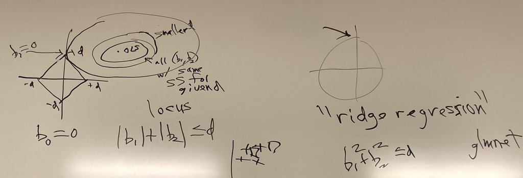

Artwork courtesy of Professor Matloff

Example: Model represented by $\beta_0, \beta_1 X_1, \beta_2 X_2$ where $X_1$ is height, $X_2$ is age

- Data centered so that $\beta_0 = 0$
- The concentric ellipses represent values of $\beta_1$ and $\beta_2$ with equal Sum of Squares error for a given d
- The diamond represents LASSO’s d-constraint on the weights: $|\beta_1| + |\beta_2| \leq d$
  - Going inside the diamond will increase error (bad)
  - We want to expand the ellipse until we just barely hit a point on the error boundary (most likely one of the four corners of the diamond when using LASSO)
- Why LASSO? The square-shape of the d-constraint makes it highly mathematically probable for the ellipse to reach the constraint boundary at one of the corners. The corners enable us to “eliminate” features with 0-weights.
  - Top / Bottom corners: $\beta_1 = 0$ (i.e. we don’t need to use height)
  - Left / Right corners: $\beta_2 = 0$ (i.e. we don’t need to use age)
  - Useful for **dimension reduction**, to eliminate unnecessary features
  - Use this as a preliminary step to decide which features to use/perform feature selection for subsequent models

### LASSO vs. Ridge Regression

LASSO (left) vs. Ridge (right) [Source](https://miro.medium.com/v2/resize:fit:1400/format:webp/1*Sxb7OPYTp5FAkQ72YrXrIA.png)

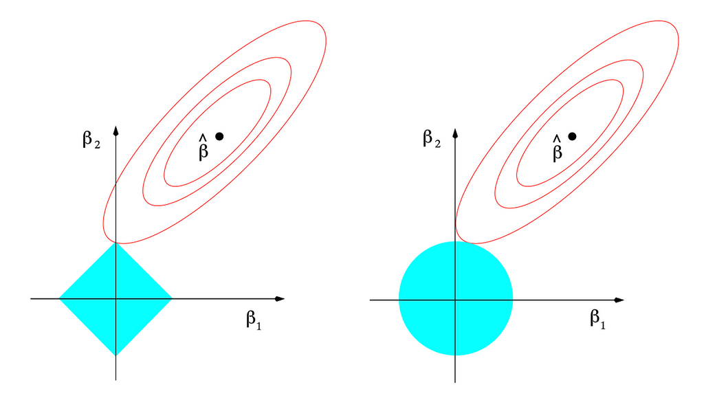

Lasso and Ridge regression: An intuitive comparison | by Thomas Le Menestrel | Towards Data Science

- LASSO Constraint uses **Absolute Value** Error
  - $|\beta_1| + |\beta_2| \leq d$
- Ridge Constraint uses **Sum Square** Error
  - $\beta_1^2 + \beta_2^2 \leq d$

### qeLASSO Example

Predict “wageinc” variable

```r
library(qeML, quietly=T)
data(pef)
w <- qeLASSO(pef,'wageinc')
```

```
## holdout set has  1000 rows
```

```r
w$coefs
```

```
## 11 x 1 sparse Matrix of class "dgCMatrix"
##                     s1
## (Intercept) -4908.0448
## age           205.0186
## educ.14      7730.5690
## educ.16      7923.3937
## occ.100     -1509.6342
## occ.101         .
## occ.102      3436.1332
## occ.106         .
## occ.140         .
## sex.1        3259.9673
## wkswrkd      1146.6999
```

```r
levels(pef$occ)
```

```
## [1] "100" "101" "102" "106" "140" "141"
```

## [Support Vector Machines](https://github.com/matloff/qeML/blob/master/inst/mdFiles/ML_Overview.md#support-vector-machines)

Note: General consensus in the ML community:

- Neural nets are good for non-tabular data (i.e. image data)
- Use boosting (i.e. random forest, but where each tree improves on the last) on tabular data

Some people think Iris dataset is immoral? Use penguin dataset instead?

- Sir Ronald Fisher developed a lot of statistics resources, such as iris dataset
- As an upperclass British dude, he had repulsive racial attitudes that garner protest against use of his datasets (be careful if you give a presentation using this data)

### SVM on Iris Data

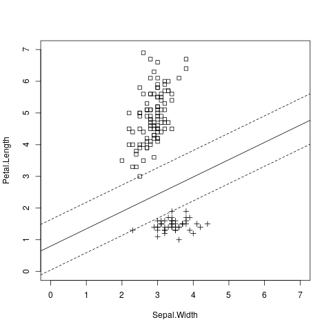

> There are 3 classes, but we are just predicting setosa species (shown by + symbols) vs. non-setosa (shown by boxes) here. Below the solid line, we predict setosa, otherwise non-setosa.

**Optimizing Margin(s):**

> SVM philosophy is that we’d like a wide buffer separating the classes, called the *margin*, denoted by the dashed lines. Data points lying on the edge of the margin are termed *support vectors*, so called because if any other data point were to change, the margin would not change.

> In most cases, the two classes are not linearly separable. So we allow curved boundaries, implemented through polynomial (or similar) transformations to the data. The degree of the polynomial is a hyperparameter.

**Optimizing Cost:**

- Small or Zero Cost: you can have any amount of points in the margin, but will not be very predictive
- Large Cost: you cannot have many points in the margin, but will be difficult to fit & prone to error

> Another hyperparameter is **cost:** Here we allow some data points to be within the margin. The cost variable is roughly saying how many exceptions we are willing to accept.

## [Linear Algebra Basics](https://github.com/matloff/fastLinearAlgebra)

(Discussion 4/27/2023: Go through lessons 1:5)